# Unit 2 Module 2b

Spatial Data Analysis with R (01:450:320)

# 1 Algebra, categorizing, and sampling

Before starting, let us define a function to load packages quietly. Since we will be using several different libraries in this module, this approach ensures our workspace remains clean and prevents installation logs or startup messages from cluttering the output.

```r
# Define a quiet loader function
load_quietly <- function(pkg) {
  if (!requireNamespace(pkg, quietly = TRUE)) {
    # Install without outputting progress bars or logs
    install.packages(pkg, dependencies = TRUE, quiet = TRUE,
                     repos = "http://cran.us.r-project.org")
  }
  # Load the library while suppressing startup messages and warnings
  suppressMessages(suppressWarnings(library(pkg, character.only = TRUE)))
}
```

Let’s move on and look at some additional raster-based analyses. The next few sections depend on objects created in the previous sections (Unit 2 Module 2a). The code to recreate those is here:

```r
# Load sdadata
load_quietly("sdadata")

bioclim <- rast(system.file("extdata/bioclim.tif", package = "sdadata"))
districts <- system.file("extdata/districts.geojson", package = "sdadata") %>%
    st_read %>% mutate(ID = 1:nrow(.))
bioclimz <- mask(x = bioclim, mask = districts)

tzar <- rast(x = ext(districts), crs = crs(districts), res = 0.1)
values(tzar) <- 1:ncell(tzar)
tzar2 <- rast(x = ext(districts), crs = crs(districts), res = 0.25)
values(tzar2) <- 1:ncell(tzar2)

distsr <- rasterize(x = districts, y = tzar, field = "ID")
distsr_rs <- resample(x = distsr, y = bioclimz, method = "near")  # match extent

species <- system.file("extdata/species.csv", package = "sdadata") %>% read_csv
speciesr <- species %>%
  dplyr::select(x, y) %>%
  mutate(count = 1) %>%
  st_as_sf(coords = c("x", "y"), crs = 4326) %>%
  rasterize(x = ., y = tzar2, field = "count", fun = sum) %>%
  print()
```

```
#> class       : SpatRaster
#> size        : 43, 43, 1  (nrow, ncol, nlyr)
#> resolution  : 0.2524466, 0.2506792  (x, y)
#> extent      : 29.58953, 40.44473, -11.76235, -0.983143  (xmin, xmax, ymin, ymax)
#> coord. ref. : lon/lat WGS 84 (EPSG:4326)
#> source(s)   : memory
#> name        :  sum
#> min value   :    1
#> max value   : 1216
```

```r
roads <- st_read(system.file("extdata/roads.geojson", package = "sdadata"))
```

```r
# And don't forget
plot_noaxes <- function(x, axes = FALSE, box = FALSE, mar = c(1, 0.5, 2, 4),
                        ...) {
  if(!class(x) %in%
     c("RasterLayer", "RasterStack", "RasterBrick", "SpatRaster")) {
    stop("This function is intended for rasters only", call. = FALSE)
  }
  par(mar = mar)
  if(class(x) %in% c("RasterLayer", "RasterStack", "RasterBrick")) {
    plot(x, axes = axes, box = box, ...)
  } else {
    plot(x, axes = axes, mar = NA, ...)
  }
}
```

## 1.1 Algebra and selection

We can do any number of raster calculations using basic mathematical expressions. Here are some very basic ones:

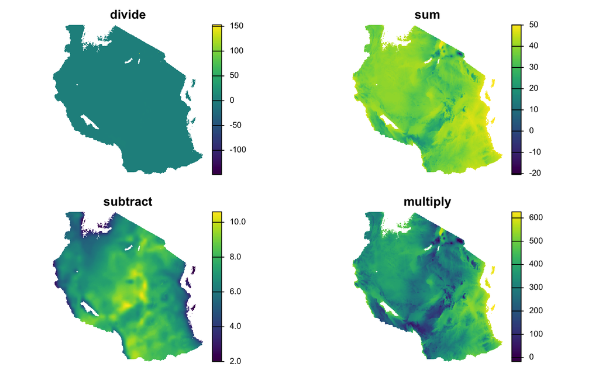

```r
# Chunk 36
r1 <- bioclimz[[1]] / bioclimz[[6]]
r2 <- bioclimz[[1]] + bioclimz[[6]]
r3 <- bioclimz[[1]] - bioclimz[[6]]
r4 <- bioclimz[[1]] * bioclimz[[6]]

s <- c(r1, r2, r3, r4)
names(s) <- c("divide", "sum", "subtract", "multiply")
plot_noaxes(s)
```

As you have seen in the previous section, we can also perform logical operations on rasters, selecting cells that meet certain criteria.

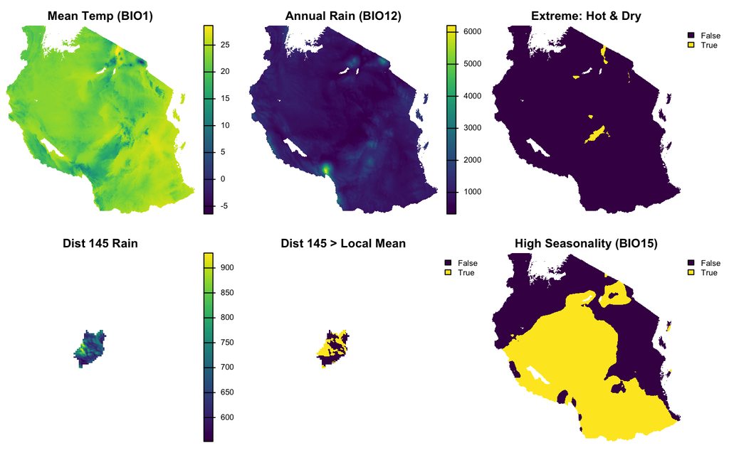

```r
# Chunk 37
# # 1. Standardize functions and layers
# bio1 = Annual Mean Temp, bio12 = Annual Precip, bio15 = Precip Seasonality
temp <- bioclimz[["bio01"]]
precip <- bioclimz[["bio12"]]
precip_cv <- bioclimz[["bio15"]]

# #2. Identify Extremes: High Heat and Low Rainfall
# (Example threshold: Temp > 25°C and Rain < 600mm)
hot_and_dry <- temp > 25 & precip < 600

# #3. Regional Focus (District 145)
# Masking Annual Rainfall to a specific district
dist145 <- distsr_rs == 145
dist_precip <- dist145 * precip
dist_precip[dist145 == 0] <- NA

# #4. Regional Threshold: Above Average Rainfall within District 145
mu_dist <- unlist(global(dist_precip, mean, na.rm = TRUE))
dist_precip_high <- dist_precip > mu_dist

# #5. National Threshold: High Seasonality
# Areas where precipitation seasonality (CV) is higher than the national mean
mu_cv <- unlist(global(precip_cv, mean, na.rm = TRUE))
high_seasonality <- precip_cv > mu_cv

# Combine for plotting
s <- c(temp, precip, hot_and_dry, dist_precip, dist_precip_high, high_seasonality)
titles <- c("Mean Temp (BIO1)", "Annual Rain (BIO12)", "Extreme: Hot & Dry",
            "Dist 145 Rain", "Dist 145 > Local Mean", "High Seasonality (BIO15)")
plot_noaxes(s, main = titles)
```

In #1, we extract the annual mean temperature, annual precipitation, and precipitation seasonality (CV) directly from the `bioclimz` dataset using their layer names. Then, in #2, we identify “climate stress” zones: cells that have both high annual mean temperatures (>25°C) and low annual rainfall (<600 mm).

## 1.2 Categorizing

Sometimes you will want to create a categorical raster from a continuous one. We will look at two different ways of doing that.

Method 1:

```
#> <SpatRaster> resampled to 500550 cells.
```

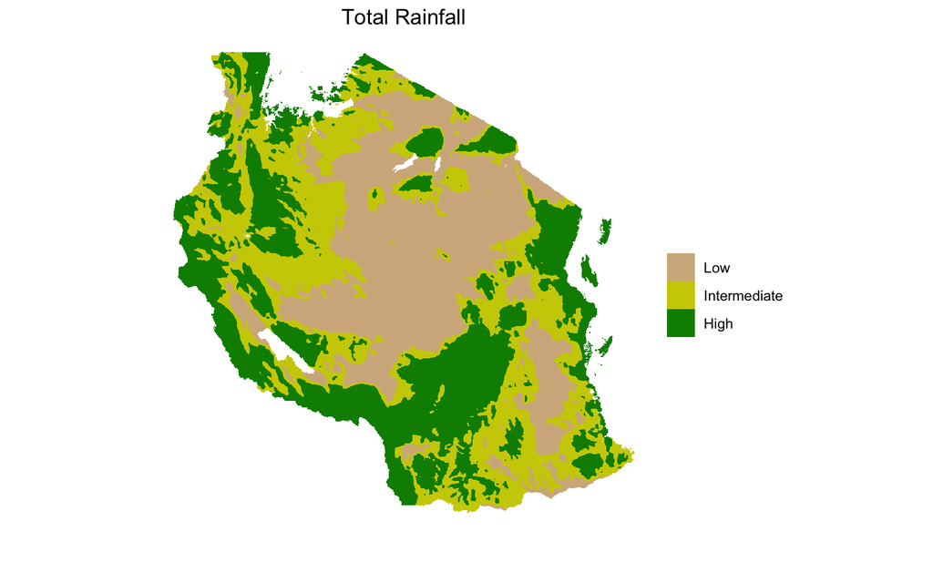

```r
load_quietly("tidyterra") # the package to plot spatRaster in a tidy way.

# Chunk 38
qtiles <- global(precip,
                 function(x) quantile(x, probs = seq(0, 1, 1/3), na.rm = TRUE))
raintotcut <- classify(x = precip, rcl = unlist(qtiles), include.lowest = TRUE)

ggplot() +
    geom_spatraster(data = raintotcut) +
    # add a title
    ggtitle("Total Rainfall") +
    # Manually set the colors
    scale_fill_manual(
        name = "",
        values = c("tan", "yellow3", "green4"),
        labels = c("Low", "Intermediate", "High"),
        na.translate = FALSE) +
    theme_void() +
    theme(
        # Set plot margin
        plot.margin = unit(c(0, 0, 2, 0), "lines"),
        # center the title
        plot.title = element_text(hjust = 0.5))
```

Method 2 is somewhat more involved:

```r
# Chunk 39
rclmat <- cbind(unlist(qtiles[1:3]), unlist(qtiles[2:4]), 1:3)
rclmat
```

```
#>            [,1] [,2] [,3]
#> X0.         324  818    1
#> X33.33333.  818 1022    2
#> X66.66667. 1022 6224    3
```

```
#> <SpatRaster> resampled to 500550 cells.
```

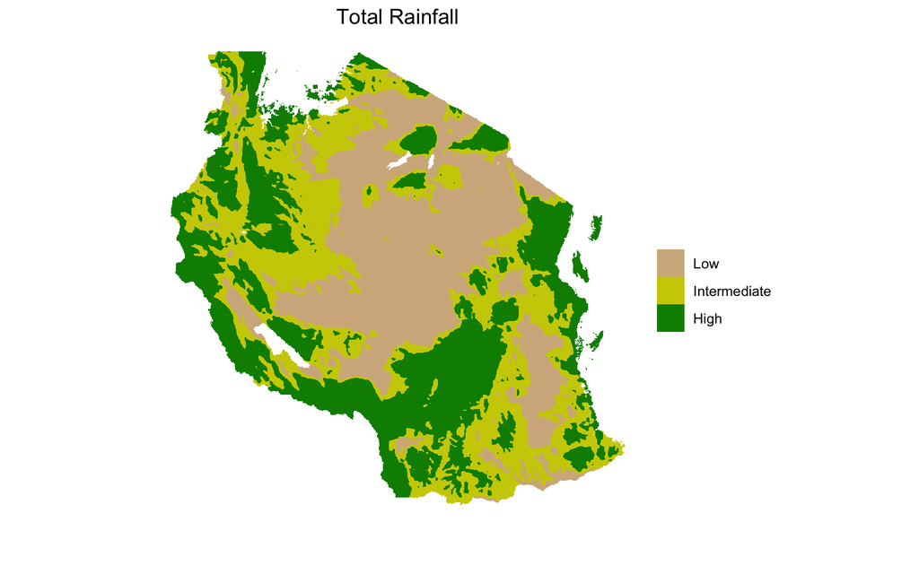

```r
# Note that the resultant raintotrcl has continuous values
raintotrcl <- classify(x = precip, rcl = rclmat, include.lowest = TRUE)

# Convert classes to a factor with desired labels/order
raintotrcl <- as.factor(raintotrcl)
levels(raintotrcl) <- data.frame(
  value = 1:3,
  label = c("Low", "Intermediate", "High"))

ggplot() +
    geom_spatraster(data = raintotrcl) +
    # add a title
    ggtitle("Total Rainfall") +
    # Manually set the colors
    scale_fill_manual(
        name = "",
        values = c("tan", "yellow3", "green4"),
        labels = c("Low", "Intermediate", "High"),
        na.translate = FALSE) +
    theme_void() +
    theme(
        # Set plot margin
        plot.margin = unit(c(0, 0, 2, 0), "lines"),
        # center the title
        plot.title = element_text(hjust = 0.5))
```

In the first step, we reuse the previously calculated terciles to create a reclassification matrix (`rclmat`). This matrix contains the lower bound of the range of the category in column 1, the upper bound in column 2, and then the new class value that will be assigned in column 3. There are three rows, one per category. This matrix is passed to the `rcl` argument of `classify`, in which we also specify the same `include.lowest = TRUE` argument.

This approach requires slightly more work (e.g. we typically need to convert the resultant raster into factor), but there are cases where you might need to use it, e.g. to reclassify another categorical raster using non-sequential categories.

## 1.3 Sampling

Many analyses use data sampled from a raster. For example, you might have coordinates for places where you collected field data, and need to collect rasterized environmental data for those locations. The `extract` function is great for this.

### 1.3.1 Extract

From the description of `extract`, the function’s purpose is to:

> Extract values from a Raster* object at the locations of other spatial data. You can use coordinates (points), lines, polygons or an Extent (rectangle) object. You can also use cell numbers to extract values.

Here we will use points and polygons:

```r
# Chunk 40
# #1
species_env <- species %>%
  st_as_sf(coords = c("x", "y")) %>%
  mutate(rain = terra::extract(x = precip, y = .)[, 2]) %>%
  mutate(district = terra::extract(x = distsr_rs, y = .)[, 2]) %>%
  print
```

```
#> Simple feature collection with 6951 features and 6 fields
#> Geometry type: POINT
#> Dimension:     XY
#> Bounding box:  xmin: 29.91544 ymin: -11.09595 xmax: 38.79323 ymax: -1.44546
#> CRS:           NA
#> # A tibble: 6,951 × 7
#>    family       species            month  year             geometry  rain district
#>  * <chr>        <chr>              <dbl> <dbl>              <POINT> <dbl>    <dbl>
#>  1 Elephantidae Loxodonta africana     6  2012 (34.08678 -2.276964)   787       74
#>  2 Bovidae      Syncerus caffer        6  2012   (35.75882 -3.5614)   666        3
#>  3 Bovidae      Syncerus caffer        6  2012 (35.44965 -3.230564)  2296        7
#>  4 Felidae      Panthera pardus        6  2012 (34.96447 -2.475424)   736       79
#>  5 Elephantidae Loxodonta africana     6  2012 (35.13262 -1.883995)   881       79
#>  6 Bovidae      Syncerus caffer        6  2012   (35.73392 -3.0035)  1904        7
#>  7 Elephantidae Loxodonta africana     6  2012 (35.61116 -3.004654)  2499        7
#>  8 Elephantidae Loxodonta africana     6  2012 (35.97219 -3.429279)   603        6
#>  9 Bovidae      Syncerus caffer        6  2012 (35.12084 -1.948731)   839       79
#> 10 Elephantidae Loxodonta africana     6  2012 (35.03655 -1.983431)   804       79
#> # ℹ 6,941 more rows
```

```r
# #2
speciesdistid <- species_env %>%
  drop_na %>%
  distinct(district) %>%
  pull

distrain <- districts %>%
  filter(ID %in% speciesdistid) %>%
  terra::extract(x = precip, y = ., fun = mean) %>%
  rename(rain = bio12) %>%
  print
```

```
#>    ID      rain
#> 1   1  962.6237
#> 2   2  816.4723
#> 3   3  803.7623
#> 4   4 1016.7394
#> 5   5  759.0712
#> 6   6  965.1684
#> 7   7  653.8991
#> 8   8  583.0270
#> 9   9  653.1400
#> 10 10  688.9380
#> 11 11  709.8703
#> 12 12  629.6706
#> 13 13  617.5856
#> 14 14 1224.4511
```

[output cut: 40 more lines]

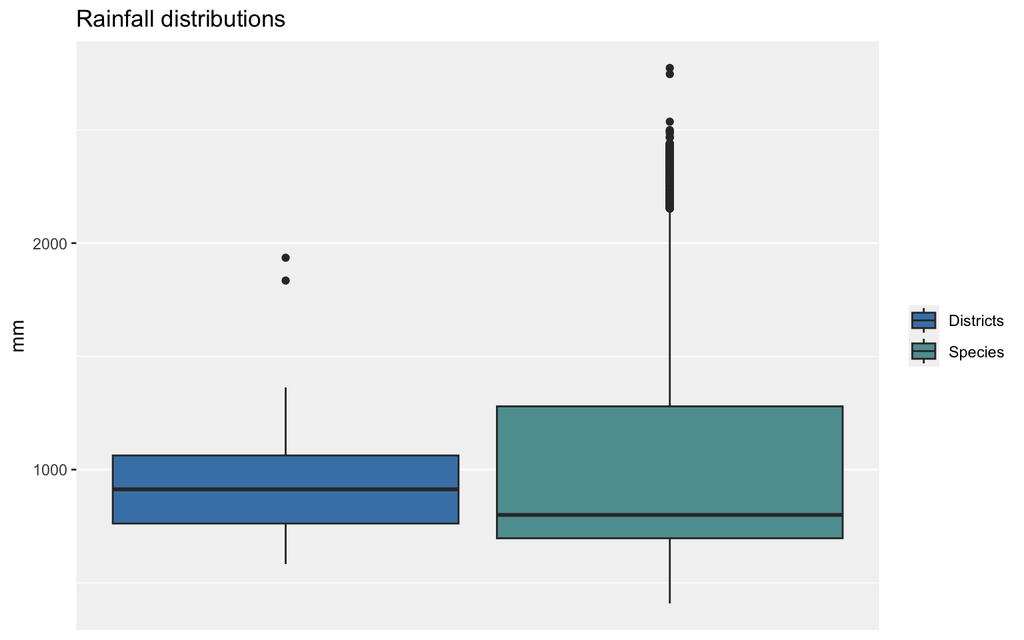

```r
# #3
rain_stats <- bind_rows(
  species_env %>%
    drop_na %>%
    dplyr::select(rain) %>%
    st_drop_geometry() %>%
    mutate(dat = "Species"),
  distrain %>%
    dplyr::select(rain) %>%
    mutate(dat = "Districts")
)

# #4
bp_theme <- theme(legend.title = element_blank(),
                  axis.text.x = element_blank(),
                  axis.ticks.x = element_blank(),
                  panel.grid.major.x = element_blank(),
                  panel.grid.minor.x = element_blank(),
                  panel.background = element_rect(fill = "grey95"))
ggplot(rain_stats) +
  geom_boxplot(mapping = aes(y = rain, fill = dat), position = "dodge2") +
  scale_fill_manual(values = c("steelblue", "cadetblue")) +
  ggtitle("Rainfall distributions") + xlab(NULL) + ylab("mm") +
  bp_theme
```

In #1, we use a pipeline to create a new `species_env` `sf`, and we pass that to the “y” argument of `terra::extract`. The first `extract` is done from the `precip` raster, the second from the `dists_rs` raster. Both extractions are wrapped in `mutate`, in order to create two new variables for `species_env`. Note that we have to specify `terra::extract` because it is masked by `dplyr::extract`, as `sdadata` loads `tidyverse` after `raster` (remember section 1.2.2 in Unit 1 Module 2). The resulting `sf` contains rainfall sum and district numbers for each species’ location.

In #2, we first pull out of `species_env` a vector of the distinct district IDs. Because `species` contains a few bad coordinates that fall outside of Tanzania, and there had `NA` values, we inserted `drop_na` into the pipeline to get rid of those. We then used `speciesdistid` to filter out the districts the species live in from `districts`, and used the result to extract from `precip` the mean rainfall from the pixels of `precip` falling within each selected district. When using `terra::extract` with polygons, if you don’t pass a value to the “fun” argument, a list is returned, in which each element contains the extracted pixel values corresponding to a particular polygon. If you give “fun” an argument (e.g. `mean`, as in this case), you get back a `data.frame` containing the resulting statistic(s) for each polygon.

In #3, we do some gymnastics in preparation for setting up `ggplot` boxplots (#4) that compare the distributions of rainfall values. That is, we set up a tibble that binds by row the extracted district and species rainfall values, which allows `ggplot` to automatically create side-by-side boxplots using `fill = dat`. We create some theme options for `ggplot` ahead of that (`bp_theme`), so that we can recycle these in the next example. The plot shows that the rainfall data within species locations provide a biased estimate of district mean rainfall.

### 1.3.2 Random sampling

Alternatively, you might want to draw a random sample directly from a raster, without all the trials and tribulations of field work (field logistics often make it hard to capture truly randomized, and thus representative, samples). `raster` has functions for this, and we will build off the previous example to demonstrate them.

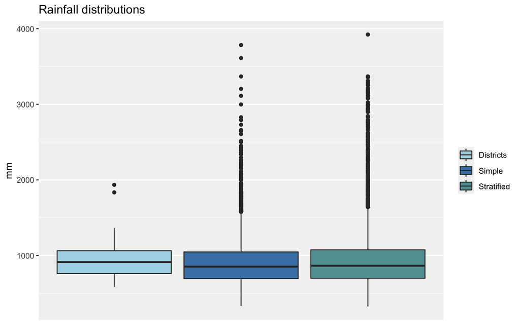

```r
# Chunk 41
# #1
speciesdistsr <- distsr_rs %in% speciesdistid
distsrspecies <- mask(x = distsr_rs, mask = speciesdistsr, maskvalue = 0)
# plot_noaxes(distsrspecies)

# #2
set.seed(1)
distsamp <- spatSample(x = distsrspecies, size = nrow(species_env),
                       cells = TRUE, na.rm = TRUE)
randrain <- precip[distsamp[, 1]]

# #3
set.seed(1)
distsamp_str <- spatSample(x = distsrspecies, method = "stratified",
                           size = nrow(species_env) / length(speciesdistid),
                           cells = TRUE)
stratrandrain <- precip[distsamp_str[, 1]]

# #4
rand_rain_stats <- bind_rows(
  tibble(distrain %>% dplyr::select(rain), dat = "Districts"),
  tibble(randrain %>% rename(rain = bio12), dat = "Simple"),
  tibble(stratrandrain %>% rename(rain = bio12), dat = "Stratified")
) %>% drop_na

ggplot(rand_rain_stats) +
  geom_boxplot(mapping = aes(y = rain, fill = dat), position = "dodge2") +
  scale_fill_manual(values = c("lightblue", "steelblue", "cadetblue")) +
  ggtitle("Rainfall distributions") + xlab(NULL) + ylab("mm") +
  bp_theme
```

In #3 we apply the more correct way of collecting a representative sample from units of varying size, which is to stratify the sample by districts. To do this, we uses the function `spatSample` again with “method” set to “stratified”, which uses the district IDs in `distsrspecies` to create the strata, and the “size” argument specifies the size of the sample that should be drawn from **each stratum** (i.e. district). To estimate that size, we divide `nrow(species_env)` by the number of species-hosting districts, so that we end up with a total sample equal to 6951. Note that this function merely ensures that the same sample size is drawn from each stratum (district), and does not make the sample size in each stratum proportional to its area.

In #4, we redo the boxplots, showing the results from the two approaches to random sampling alongside the distribution of district mean rainfall values (extracted in Chunk 40). Both approaches produce statistics that are quite representative of the district rainfall. The stratified approach is closest, as the median aligns more closely with that of `distrain` (the boxplot for “Districts” in the plot).

## 1.4 Practice

### 1.4.1 Questions

1. What are two ways of converting a continuous to categorical raster?
2. What are two methods of sampling from a `spatRaster`? Are the others (a look in `terra`s help files will be informative)?

### 1.4.2 Code

1. Use `app` (must use `app`) to find the difference between the “Max Temperature of Warmest Month” (bio05) and the “Min Temperature of Coldest Month” (bio06) for every cell in `bioclimz`.
2. Use raster algebra to find the country-wide average for this calculated Temperature Range, and then identify which areas of Tanzania have a range that is greater than that average.
3. Create a new categorical raster from `precip`, using the quantiles to define the new category boundaries together with the cut method applied to `classify`. Use `plot_noaxes` to show the result.
4. Create a new sub-sample of rasterized districts, `randdistsr`, totalling 15 districts randomly selected using `dplyr::sample_n` (use a seed of 11) from `districts`. Use `precip` as the rasterization target. Mask `precip` so that it is confined to those districts (with NAs values replacing the values in the other districts). Call it `newrandrain`.
5. Use `spatSample` with a size of 300 to get a random sample of rainfall values from `newrandrain` (use a seed of 1), saving the result as `randsamp`. Use `spatSample` with `cell = TRUE` to get a sample of 300 / 15 samples from `randdistsr`. Use the cell IDs to extract the rainfall values from `newrandrain`, saving the output vector as `stratsamp`. Create a tibble that binds these two vectors by row (as in Chunk 41 #4), and then plot the two results as side-by-side boxplots with `ggplot`.

# 2 Terrain analysis, interpolation, and modeling

## 2.1 Terrain analysis

We’ll start off this section doing some terrain analysis, with a few little asides on the way to illustrate pixel area and some more plotting skills.

First we need a digital elevation model. The package `geodata` (note, you will likely have to install this using `install.packages("geodata")`) provides several very nice functions that allows us to download several different gridded geographic datasets, which includes DEMs:

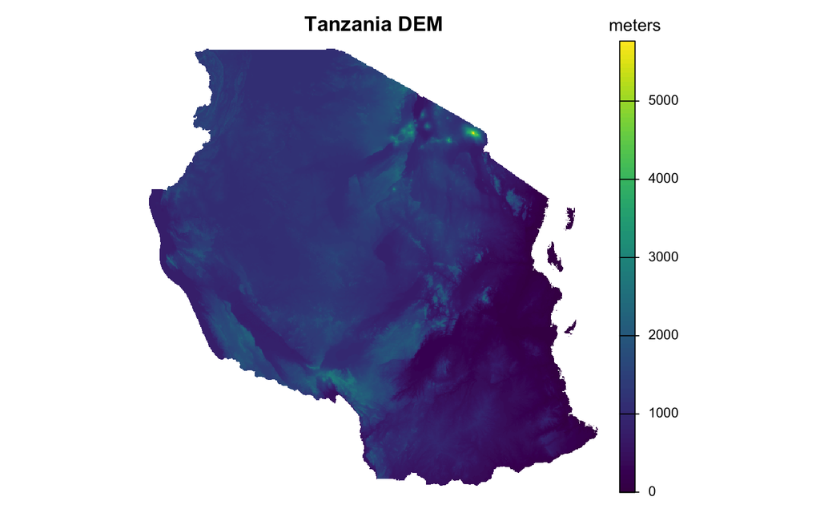

```r
# Chunk 42
load_quietly("geodata") # load geodata package

dem <- geodata::elevation_30s(country = "TZA", path = tempdir())
plot_noaxes(dem, main = "Tanzania DEM", plg = list(title = "meters"))
```

The help file for `geodata::elevation_30s` tells us the following datasets are available:

> Elevation data for any country. The main data source is Shuttle Radar Topography Mission (SRTM) , specifically the hole-filled CGIAR-SRTM (90 m resolution) from https://srtm.csi.cgiar.org/. These data are only available for latitudes between -60 and 60.

> The 1 km (30 arc seconds) data were aggregated from SRTM 90 m resolution data and supplemented with the GTOP30 data for high latitudes (>60 degrees).

There are two other version (`..._3s` and `..._global`), representing different resolutions and extents, which you can explore further at your leisure. In our example, we choose the coarser 1 km aggregated version of the SRTM DEM, for ease of download, and specify that we want it for Tanzania. `geodata` has functions for many other datasets also.

### 2.1.1 Pixel resolution/area

The DEM we downloaded is in decimal degrees with a resolution of 0.008333333°, which means the area of each pixel varies through Tanzania. To illustrate that, we use a nice function that `terra` provides, which lets you calculate the pixel areas, even when the raster is in geographic coordinates:

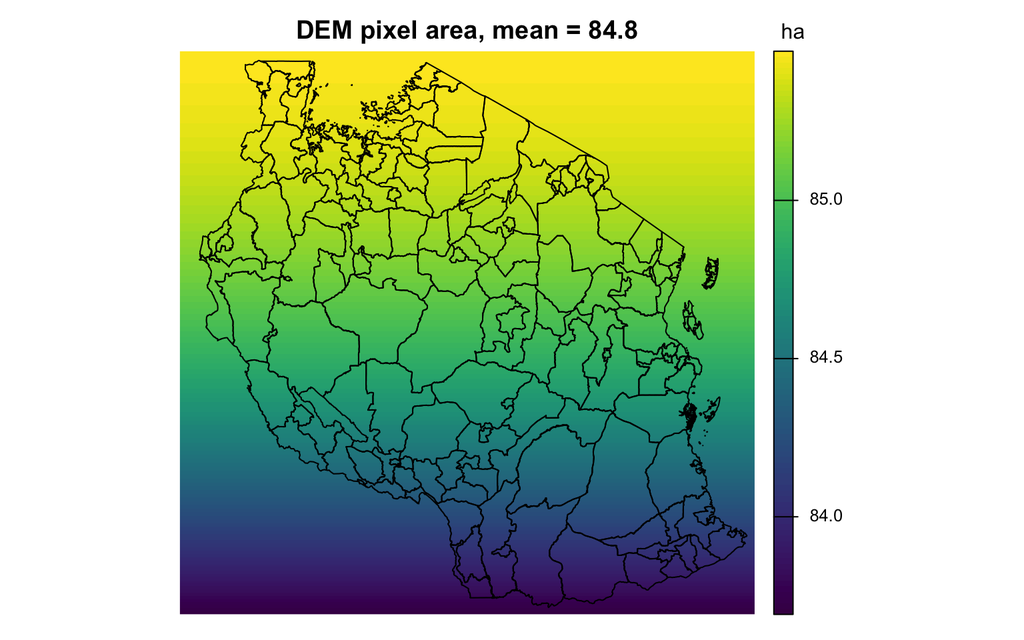

```r
# Chunk 43
demarea <- cellSize(dem, unit = "ha")
plot_noaxes(demarea, plg = list(title = "ha"),
            main = paste0("DEM pixel area, mean = ",
                         round(global(demarea, mean), 1)))
plot(st_geometry(districts), add = TRUE)
```

The result is in hectares (as specified in the argument to `cellArea`), and you can see that the area of each pixel falls as the distance from the equator increases (this is why we use equal area projections to calculate area).

### 2.1.2 An aside on plot annotation

Although we covered graphics in the previous unit, let’s look a bit more at plot adornments for a second. Notice in the last two plots how we use the “plg” argument in `plot_noaxes` to put a title over the legend bar.

There are some other things we can do to plots to add symbols to text within the plots: `expression` and several other functions can be used to annotate plots with more complex mathematical formulae:

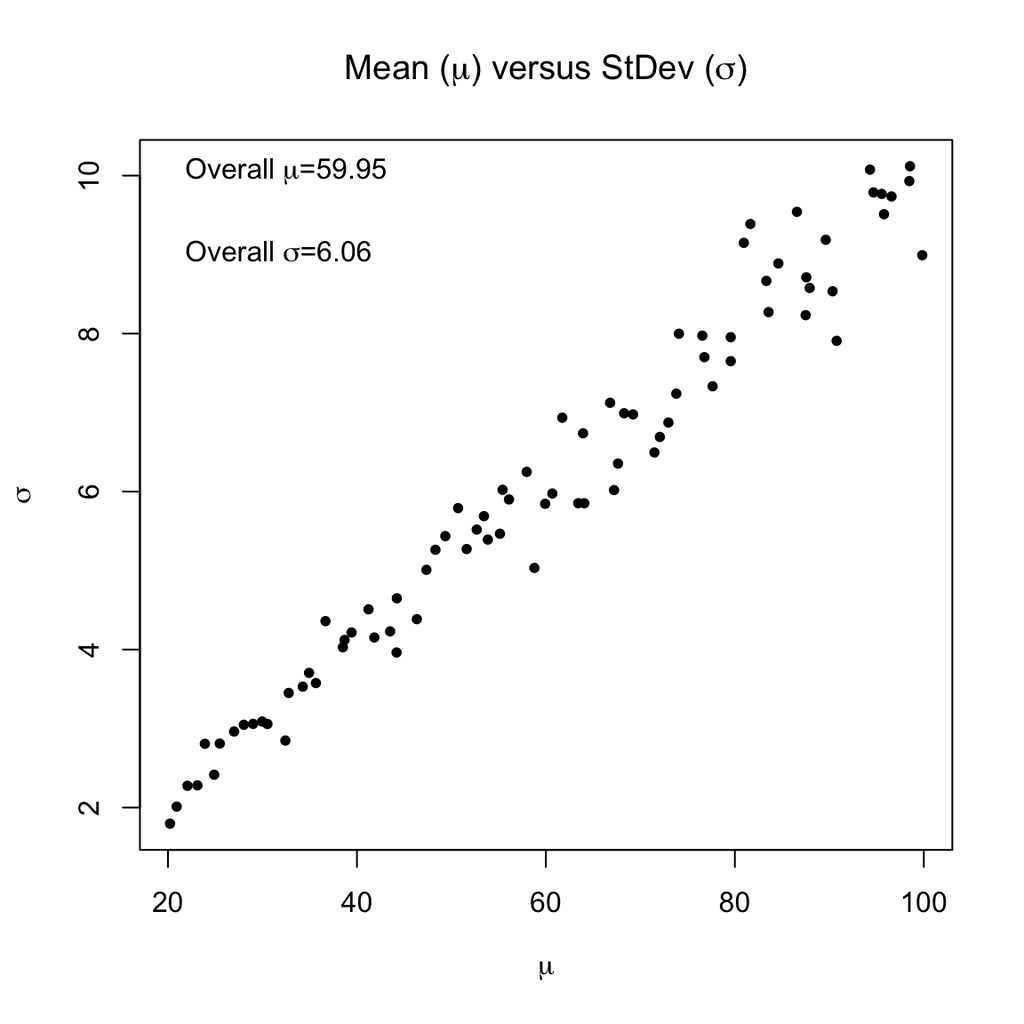

```r
# Chunk 44
set.seed(1)
a <- sapply(20:100, function(x) rnorm(n = 100, mean = x, sd = x / 10))
mu <- colMeans(a)  # means
mumu <- round(mean(mu), 2) # mean of mean
sdev <- apply(a, 2, sd)  # stdevs
musd <- round(mean(sdev), 2)  # mean of stdevs
plot(mu, sdev, xlab = expression(mu), ylab = expression(sigma), pch = 20,
     main = expression(paste("Mean (", mu, ") versus StDev (", sigma, ")")))
text(x = 20, y = 10, pos = 4,
     label = substitute(paste("Overall ", mu, "=", a), list(a = mumu)))
text(x = 20, y = 9, pos = 4,
     label = substitute(paste("Overall ", sigma, "=", a), list(a = musd)))
```

The example above shows how more advanced plot annotations can be done. It also shows that the code can get somewhat complicated; it always takes a ton of time and a number of internet searches to figure out how to do this. We won’t explain this in detail here, but the code provides a template that you can hack at if you want to get fancy with labelling your plots.

### 2.1.3 Basic terrain variables

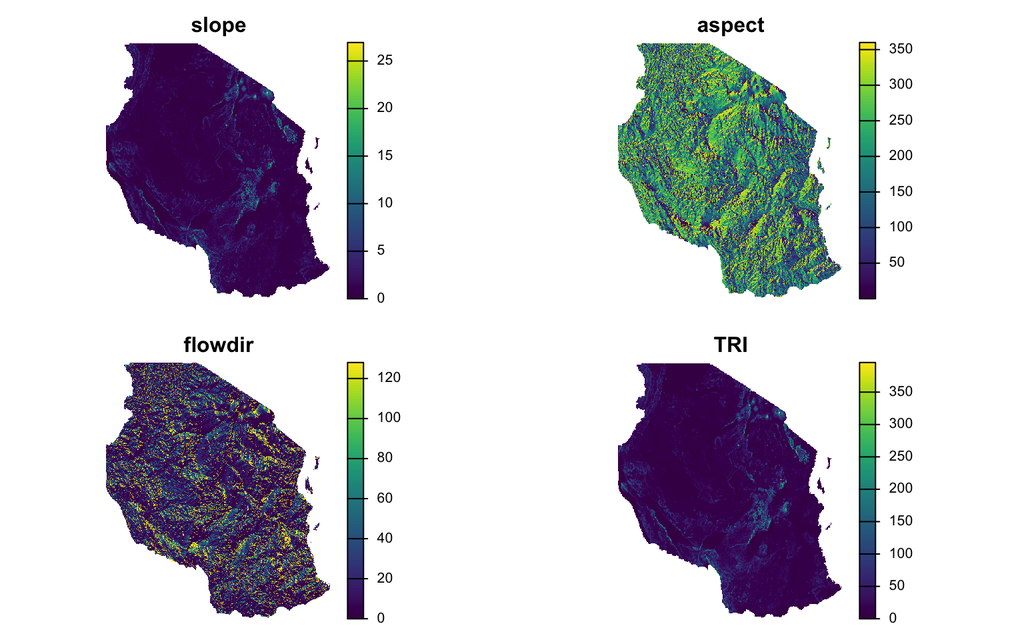

```r
# Chunk 45
# #1
tzar <- rast(x = ext(districts), crs = crs(districts), res = res(dem))
values(tzar) <- 1:ncell(tzar)
tzar_alb <- project(x = tzar, y = crs(roads), res = 1000, method = "near")
demalb <- project(x = dem, y = tzar_alb)  # default is bilinear

# #2
vars <- c("slope", "aspect", "flowdir", "TRI")
terrvars <-  lapply(1:length(vars), function(x) {
  tv <- terrain(x = demalb, v = vars[x], unit = "degrees")
}) %>% do.call(c, .)
names(terrvars) <- vars

plot_noaxes(terrvars)
```

So we create (#1) a 1 km projected version of the DEM, allowing the default bilinear interpolation to do its work during reprojection.

## 2.2 Interpolation

Interpolating between point values is a fairly common GIS analysis. The `interpolate` function of raster allows you to do this using a number of different types of models, such as kriging and inverse distance weighting. We are going to demonstrate both approaches, drawing on functions provided by the `gstat` package (please install it):

```r
# Chunk 46
load_quietly("gstat") # load gstat package

# #1
raintotalb <- project(x = precip, y = crs(roads), res = 5000)
names(raintotalb) <- "rain"
r <- rast(ext(raintotalb), res = res(raintotalb),
          crs = crs(raintotalb), vals = 1)

# #2
set.seed(1)
rainsamp <- spatSample(raintotalb, size = 1000, xy = TRUE, na.rm = TRUE)
# head(rainsamp)

# #3
invdist <- gstat(id = "rain", formula = rain ~ 1, locations = ~x + y,
                 data = rainsamp)
invdistr <- interpolate(object = r, model = invdist)
```

```
#> [inverse distance weighted interpolation]
#> [inverse distance weighted interpolation]
```

```r
invdistrmsk <- mask(x = invdistr[[1]], mask = raintotalb)

# #4
v <- variogram(object = rain ~ 1, locations = ~x+y, data = rainsamp)  # a
m <- fit.variogram(object = v, model = vgm("Sph"))  # b
m
```

```
#>   model    psill    range
#> 1   Nug 25796.39      0.0
#> 2   Sph 97898.75 306389.9
```

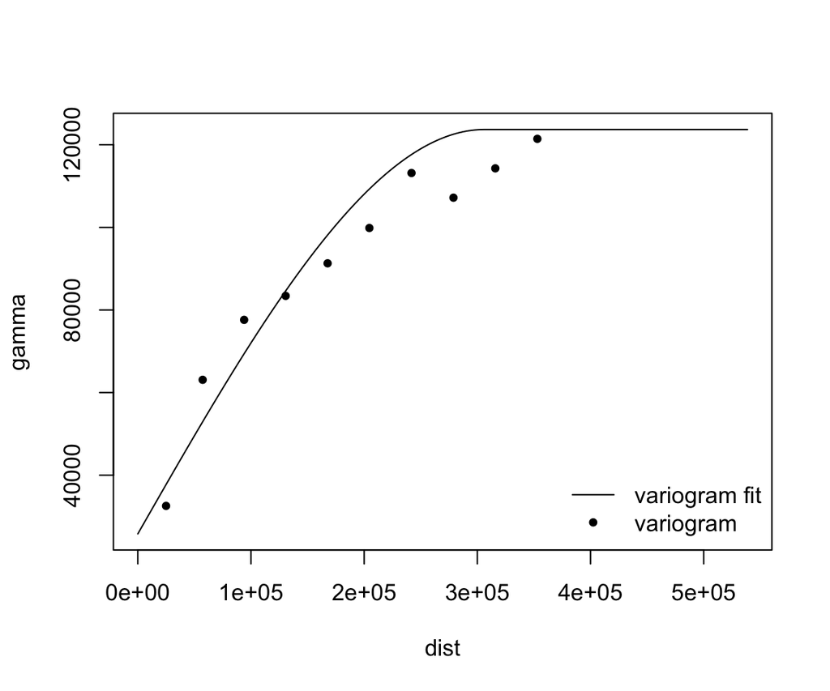

```r
plot(variogramLine(m, max(v[, 2])), type = "l")  # c
points(v[, 2:3], pch = 20)  # d
legend("bottomright", legend = c("variogram fit", "variogram"),
       lty = c(1, NA), pch = c(NA, 20), bty = "n") # e
```

```r
# #5
ordkrig <- gstat(id = "rain", formula = rain ~ 1, data = rainsamp,
                 locations = ~x+y, model = m)
ordkrigr <- interpolate(object = r, model = ordkrig)
```

```
#> [using ordinary kriging]
#> [using ordinary kriging]
```

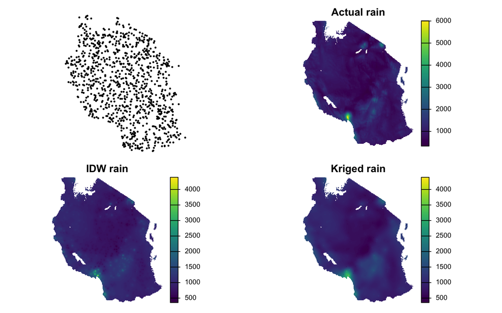

```r
ordkrigrmsk <- mask(x = ordkrigr[[1]], mask = raintotalb)

raininterp <- c(list(raintotalb, invdistrmsk, ordkrigrmsk))
titles <- c("Actual rain", "IDW rain", "Kriged rain")
par(mfrow = c(2, 2), mar = c(0, 0, 1, 0))
plot(st_as_sf(rainsamp, coords = c("x", "y"))$geometry, pch = 20, cex = 0.5)
for(i in 1:3) plot_noaxes(raininterp[[i]], main = titles[i])
```

This example is reasonably complex, both conceptually and with respect to code. We will refer you to other, non-R literature to explain how [interpolation](http://gisgeography.com/inverse-distance-weighting-idw-interpolation/) and [kriging](http://gisgeography.com/kriging-interpolation-prediction/) work, and confine our explanations to the code.

Block #1 creates an Albers projected version of `precip` (which is roughly 5 km on a side), and sets up a dummy raster (`r`) that will be our interpolation target, i.e. it provides the spatial parameters we want our prediction surface to have. #2 then draws a random sample from across the reprojected rainfall raster, providing a set of point observations of rainfall. #3 runs the code for an inverse distance weighted (IDW) interpolation (each cell between the sample points is given a new value that is the weighted mean of the rainfall values collected at the points nearest to it; the weight is determined by the distance to each point). The interpolation model is set up by the `gstat` function, using the coordinates x and y as the locations. `terra::interpolate` takes the model and applies it to `r`, making the new `invdistr` raster, which we then mask to the outline of Tanzania (`invdistrmsk`), selecting just the first layer which provides the predicted value.

In #4, we provide the initial steps for implementing ordinary kriging. Line a calculates the variogram, which measures the spatial autocorrelation between rainfall values. Line b fits a spherical variogram model. Lines c-e plot the variogram (changes in semivariances with distance) and the spherical model we fit to estimate that semivariance.

Block #5 takes the fitted variogram model (`m`) and uses that to create the rainfall surface. The steps in this block are basically the same as in #3, except that we use the kriging model.

## 2.3 Distance

If you want to calculate how far any point on a grid is from a particular point or points, `terra` offers a few functions for finding euclidean distances:

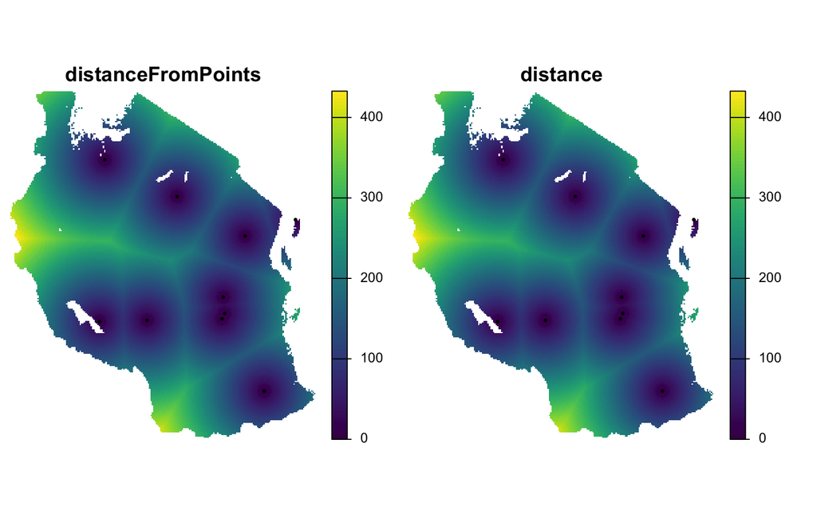

```r
# Chunk 47
# #1
set.seed(1)
randsamp <- spatSample(raintotalb, size = 10, xy = TRUE, na.rm = TRUE) %>%
  st_as_sf(coords = c("x", "y"), crs = st_crs(roads))

# #2
ptdistr <- distance(x = raintotalb, y = randsamp)
ptdistrmsk <- mask(ptdistr, raintotalb)

# #3
randsampr <- rasterize(randsamp, y = raintotalb)
ptdistr2 <- distance(randsampr)
ptdistrmsk2 <- mask(ptdistr2, raintotalb)

s <- c(ptdistrmsk, ptdistrmsk2) / 1000
names(s) <- c("distanceFromPoints", "distance")
par(mfrow = c(1, 2), oma = c(0, 0, 0, 1))
for(i in 1:nlyr(s)) {
  plot_noaxes(s[[i]], main = names(s)[i])
  plot(st_geometry(randsamp), pch = 20, cex = 0.5, add = TRUE)
}
```

In #1, we draw 10 randomly selected points from `raintotalb` and create an `sf` objects called `randsamp`. Here we are interested just in the spatial locations, not the values.

In #2, we use the `distance` function to find how far any given point in an input raster (`raintotalb`) is from the xy locations contained in `randsamp`. `raintotalb` serves here simply to provide the dimensions of the raster surface from which we want to calculate distance values. We mask the resulting distance surface (`ptdistr`) to confine the results to Tanzania’s borders.

Block #3 does pretty much the same thing, but in this case we use the `distance` function applied to the rasterized points (where the only cells having values are the cells underlying the points that were rasterized–the rest are NA) and calculates the distances from every other cell (the NA values) to the nearest rasterized point having a non-NA value.

The plot shows that the two approaches produce identical results.

Beyond this, there are more sophisticated distance analyses that can be done, such as cost distance analysis, which are provided by the package `gdistance`.